# Data analysis of developer responses

# Load data

```r
data <- read.csv( file = "./clus_data.csv", stringsAsFactors = FALSE )
#write.csv( x = data[,-1], file = "./clus_data_new.csv", row.names = FALSE )
numericColumns <- sapply(data, is.numeric)
```

```r
summary(as.data.frame(unclass(data)))
```

[output not shown]

## Removing/marking outliers

The column JOBTIME has the values 9999 that would mess up some of the plots and statistics below.

```r
sum( data$JOBTIME > 200 , na.rm=T)
```

```
[1] 8
```

Turn values that too large into NA’s.

```r
data$JOBTIME <- ifelse( data$JOBTIME > 200, NA, data$JOBTIME)
```

# Mosaic plots

It is a good idea to visualize the conditional probabilities between different columns.

## Role vs gender

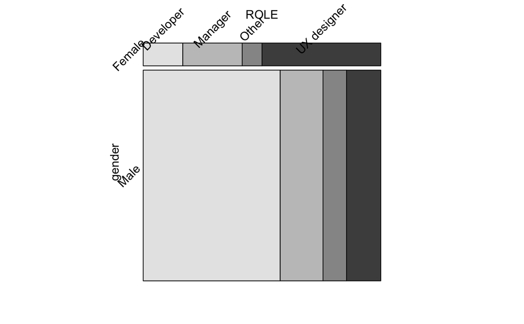

```r
mosaic( ROLE ~ gender, data = data, rot_labels=c(45,45,45,45)  )
```

In the plot above we can see that the interviewed females are much more likely to be UX designers and managers than developers.

## Role vs age

From the plots in this sub-section we can see:

- that there are no (interviewed) managers between 21-30;
- people older than 50 are much less likely to work in the industry (or answer interview questions);
- people older than 50 are much more likely to be managers, compared to the other age groups.

[figure not shown]

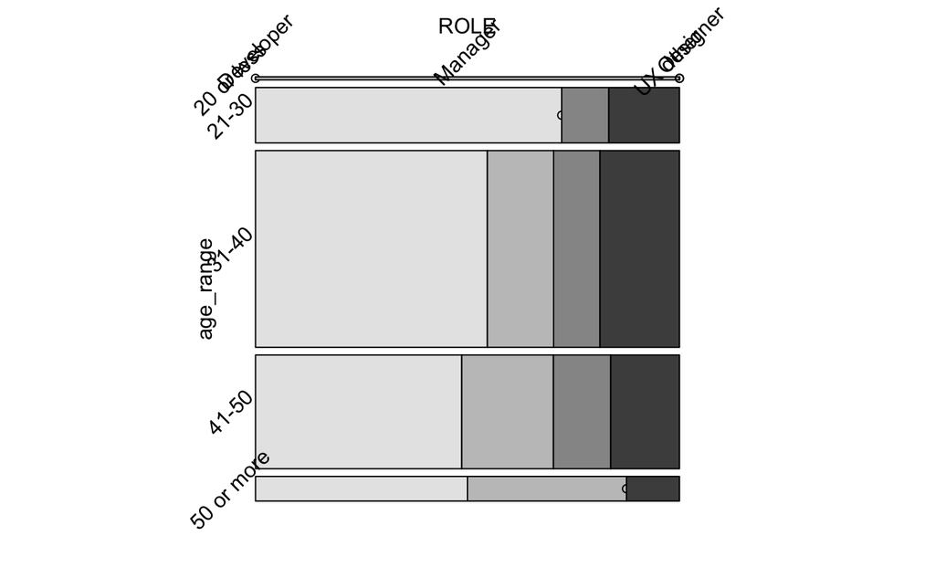

```r
mosaic( ROLE ~ age_range, data, rot_labels=c(45,45,45,45) )
```

# Clustering

Using hierarchical clustering and visualizing with a heat-map.

```r
d3heatmap( data[,numericColumns][,-1], Rowv = TRUE, Colv = FALSE, scale = "column", na.rm = TRUE )
```

[interactive chart not shown]

### Correlations benween coliumns

Correlations for all numerical columns:

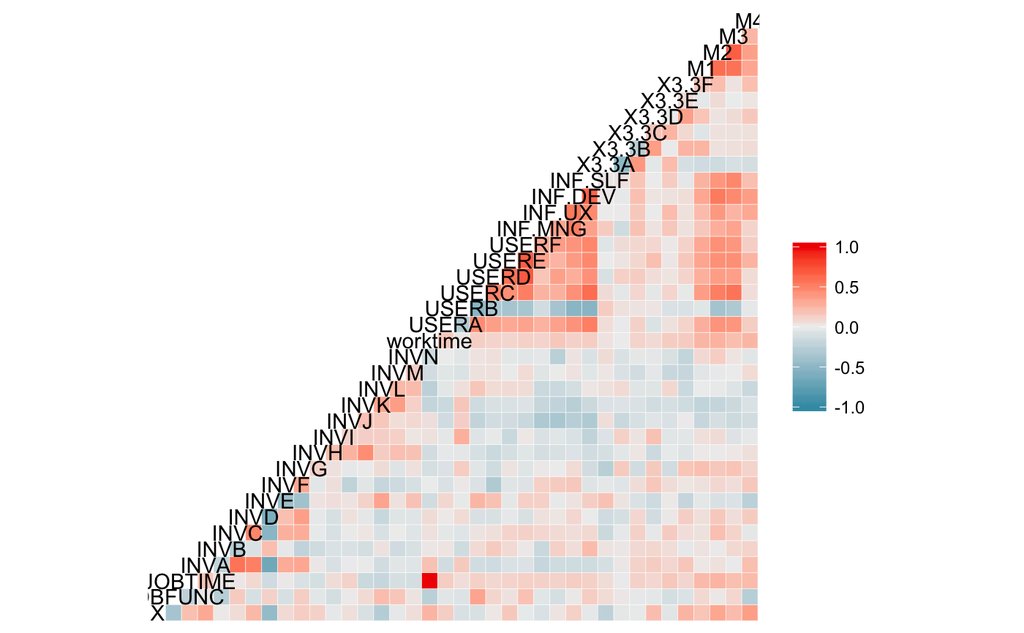

```r
qData <- data[, grepl("M",colnames(data)) & numericColumns ]
qData <- data[, numericColumns ]
#qData <- qData[ rowSums( is.na(qData) ) < 6, ]
GGally::ggcorr( qData, method = c("pairwise","spearman") )
```

It is a good idea to explain the correlations that are close to 1 and -1. Do they make sense, etc.

Correlations for selected numerical columns:

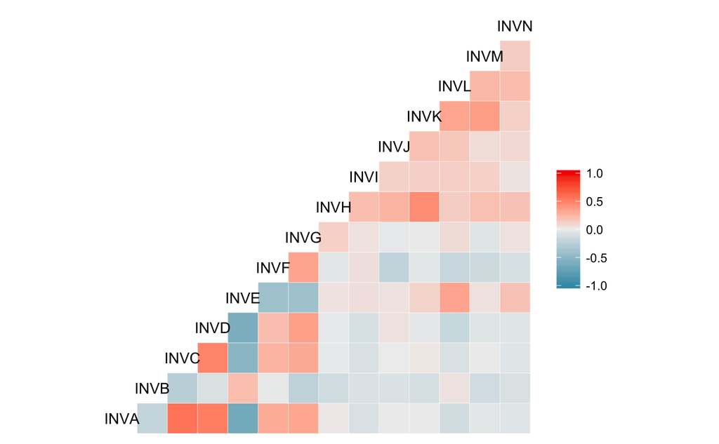

```r
# Numerical columns starting with "INV".
qData <- data[, grepl("^INV",colnames(data)) & numericColumns ]
# Removing rows that have too many NA's.
qData <- qData[ rowSums( is.na(qData) ) < 6, ]
GGally::ggcorr( qData, method = c("pairwise","spearman") )
```

# Average interviewees per class

[output not shown]

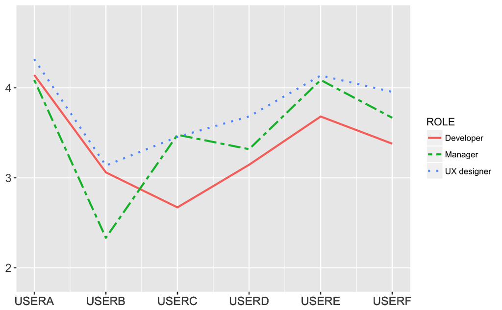

```r
ggplot(subset(group_means, ROLE %in% c("Developer", "Manager", "UX designer")), aes(x=as.numeric(variable), y=mean, color=ROLE, linetype=ROLE)) + geom_line(size=1) +
  scale_linetype_manual(values=c("solid", "twodash", "dotted")) +
  scale_x_continuous(labels=as.character(group_means$variable), breaks=as.numeric(group_means$variable))+
  theme(axis.text=element_text(size=12))+
  theme(axis.title.x=element_blank(),
        #axis.text.y=element_blank(),
        #axis.ticks.x=element_blank(),
        axis.title.y=element_blank()) +
  scale_y_continuous(limits = c(2, 4)) + scale_y_discrete(limits= c(2, 3, 4))
```